# ANLY 512 - Problem Set 3

Exploring the Grammar of Graphics

2017-03-28

## Objectives

The objectives of this problem set is to gain experience working with the `ggplot2` package for data visualization. To do this I have provided a series of graphics, all created using the `ggplot2` package. Your objective for this assignment will be write the code necessary to **exactly** recreate the provided graphics.

When completed submit a link to your file on rpubs.com. Be sure to include `echo = TRUE` for each graphic so that I can see the visualization and the code required to create it.

### Vis 1

This graphic is a traditional stacked bar chart. This graphic works on the `mpg` dataset, which is built into the `ggplot2` library. This means that you can access it simply by `ggplot(mpg, ....)`. There is one modification above default in this graphic, I renamed the legend for more clarity.

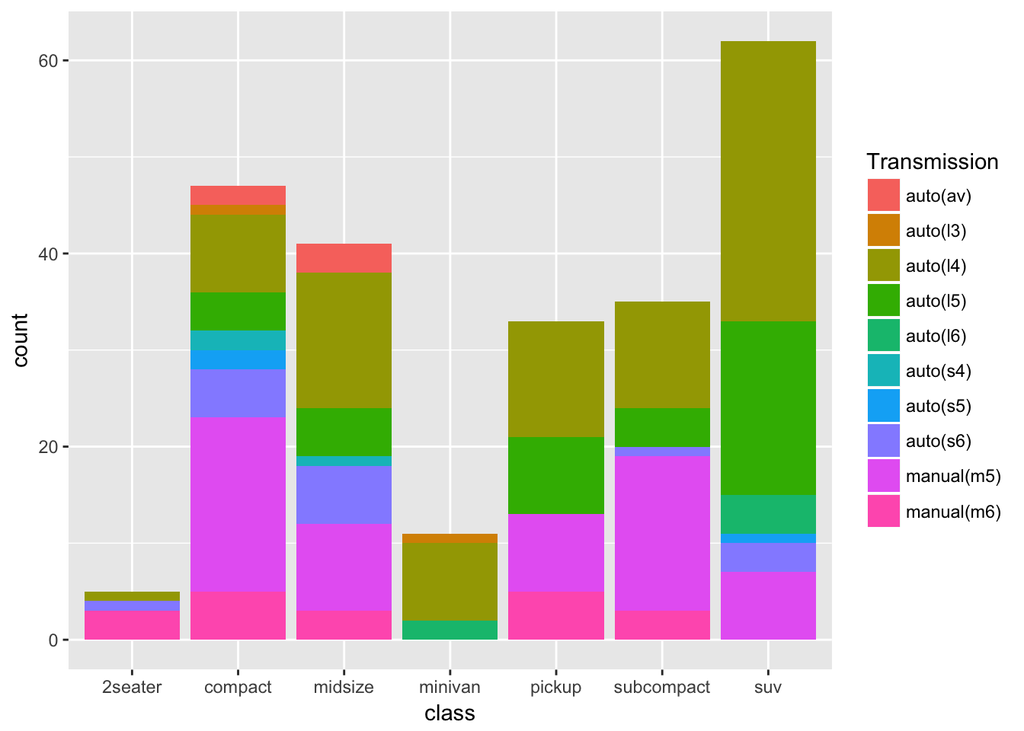

### Vis 2

This boxplot is also built using the `mpg` dataset. Notice the changes in axis labels, and an altered `theme_XXXX`

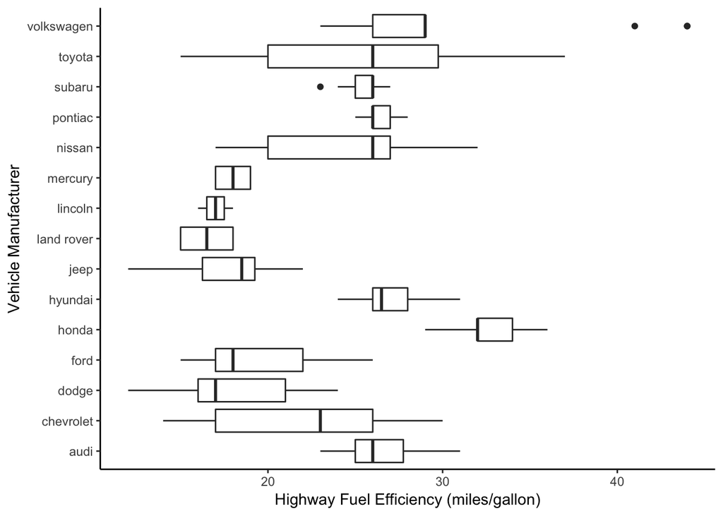

### Vis 3

This graphic is built with another dataset `diamonds` a dataset also built into the `ggplot2` package. For this one I used an additional package called `library(ggthemes)` check it out to reproduce this view.

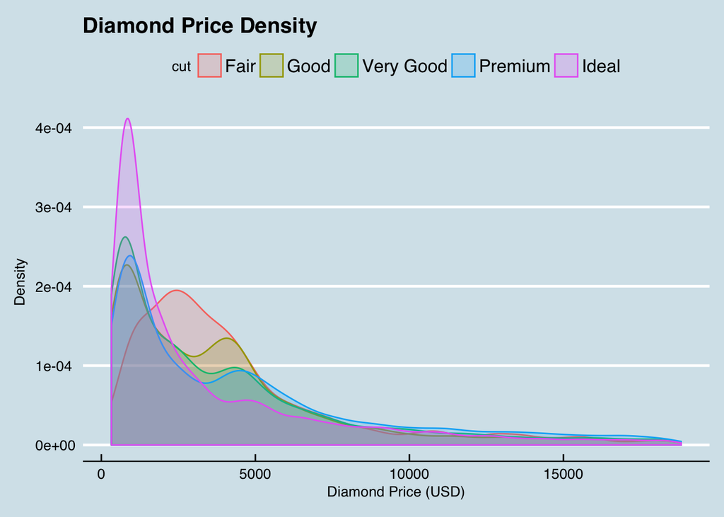

### Vis 4

For this plot we are changing vis idioms to a scatter plot framework. Additionally, I am using `ggplot2` package to fit a linear model to the data all within the plot framework. Three are edited labels and theme modifications as well.

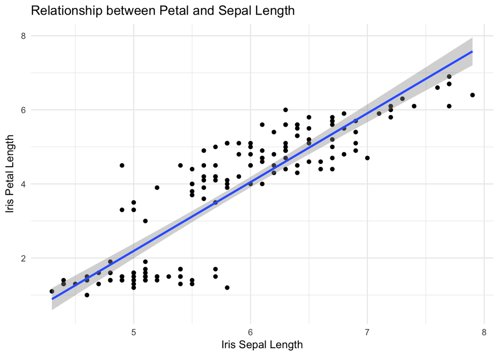

### Vis 5

Finally, in this vis I extend on the last example, by plotting the same data but using an additional channel to communicate species level differences. Again I fit a linear model to the data but this time one for each species, and add additional theme and labeling modicitations.

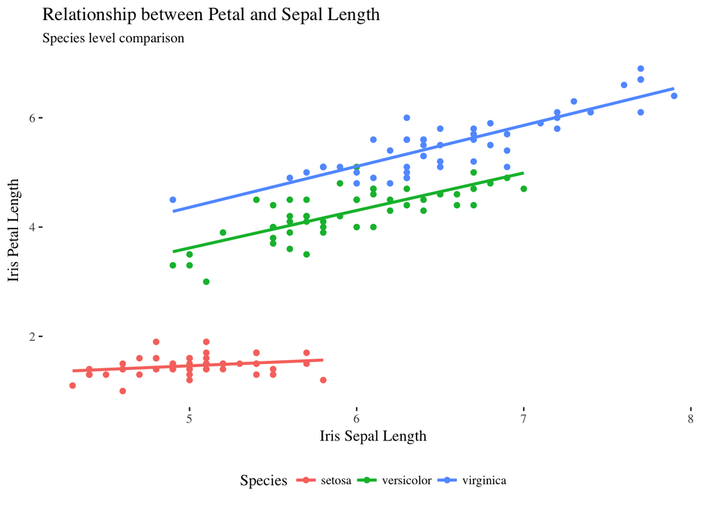